# shinde_4

Ajinkya Shinde

16th May 2018

### 1. Relevant R Code

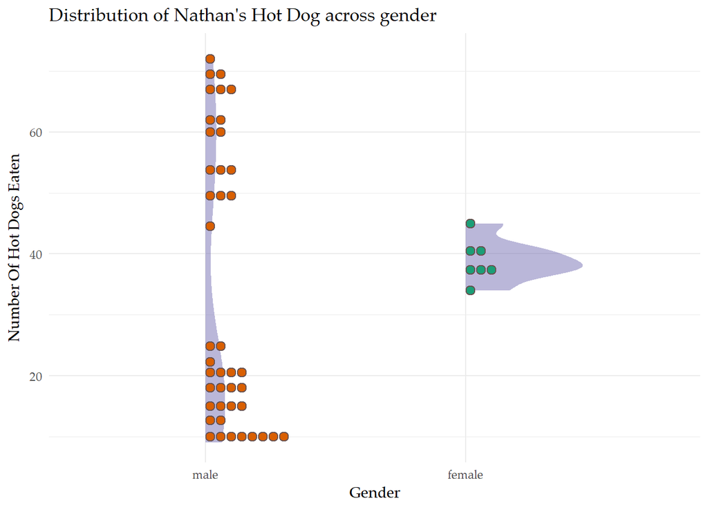

```r
"%||%" <- function(a, b) {
  if (!is.null(a)) a else b
}

geom_flat_violin <- function(mapping = NULL, data = NULL, stat = "ydensity",
                        position = "dodge", trim = TRUE, scale = "area",
                        show.legend = NA, inherit.aes = TRUE, ...) {
  layer(
    data = data,
    mapping = mapping,
    stat = stat,
    geom = GeomFlatViolin,
    position = position,
    show.legend = show.legend,
    inherit.aes = inherit.aes,
    params = list(
      trim = trim,
      scale = scale,
      ...
    )
  )
}

#' @rdname ggplot2-ggproto
#' @format NULL
#' @usage NULL
#' @export
GeomFlatViolin <-
  ggproto("GeomFlatViolin", Geom,
          setup_data = function(data, params) {
            data$width <- data$width %||%
              params$width %||% (resolution(data$x, FALSE) * 0.9)

            # ymin, ymax, xmin, and xmax define the bounding rectangle for each group
            data %>%
              group_by(group) %>%
              mutate(ymin = min(y),
                     ymax = max(y),
                     xmin = x,
                     xmax = x + width / 2)
          },

          draw_group = function(data, panel_scales, coord) {
            # Find the points for the line to go all the way around
            data <- transform(data, xminv = x,
                              xmaxv = x + violinwidth * (xmax - x))

            # Make sure it's sorted properly to draw the outline
            newdata <- rbind(plyr::arrange(transform(data, x = xminv), y),
                             plyr::arrange(transform(data, x = xmaxv), -y))

            # Close the polygon: set first and last point the same
            # Needed for coord_polar and such
            newdata <- rbind(newdata, newdata[1,])

            ggplot2:::ggname("geom_flat_violin", GeomPolygon$draw_panel(newdata, panel_scales, coord))
          },

          draw_key = draw_key_polygon,

          default_aes = aes(weight = 1, colour = "grey20", fill = "white", size = 0.5,
                            alpha = NA, linetype = "solid"),

          required_aes = c("x", "y")
)
ggplot(hot_dogs, aes(y = num_eaten, x = gender)) +
  geom_flat_violin(alpha=.5,fill = "#7570b3",
                colour = NA,
                na.rm = TRUE)+
geom_dotplot(aes(fill=gender),color="#695250",binaxis = "y", position = "dodge",dotsize=0.75, stackratio= 1.1)+
  labs(y="Number Of Hot Dogs Eaten",x="Gender",title="Distribution of Nathan's Hot Dog across gender")+
  scale_fill_brewer(type="qual",palette = 2,direction = -1)+
   theme_minimal()+theme(text=element_text( family="Palatino Linotype"),legend.position="none")
```

### 2. Description of the TYPE of graph.

The graph is a dot plot to measure the spread/distribution of hot dogs eaten during Nathan’s hot dog contest across the gender

### 3. Description of the DATA you used

The data refers to the nathan’s hotdog contest dataset. In this graph, the final data frame is hot_dogs. The quantitative variable is stored in `num_eaten` i.e. number of hot dogs eaten.The qualitative variable is the gender who ate the hot dogs

### 4. Description of the AUDIENCE you are aiming for

The audience over here is someone who wants to see how each gender performed in the contest

### 5. Representation Description:

This graph shows the spread of hot dogs eaten across genders in the dataset

### 6. How to read it & What to look for

On x-axis lies the gender and on y-axis lies the number of hot dogs. This is not the same as traditional histogram where the distribution is measured on x-axis but here the co-ordinates are flipped using `bin_axis=y`

**Major Highlights** It seems that male have roughly extreme eating(either too low/high) habits as compared to the female who perform quite well since the data is cluttered around the mean of hot dogs ate by female.

### 7. Presentation tips

Since, gender is a nominal variable ,have used the discrete color palette from ColorBrewer with `type="qual"`.

### 8. Variations and alternatives

Could have used violin plot as an alternative.

### 9. How I created it

I formulated the question of what exactly I want: I wanted to see how each gender performed in the hot dog contest.So I just used the variables `gender` and `num_eaten` to see the histogram. Then used two ways to represent distribution (dotplot,flat-violin-split).